# Modelo Machine learning - Modelagem Preditiva em IoT - Previsão de Uso de Energia

# Descrição projeto

Este projeto de IoT tem como objetivo a criação de modelos preditivos para a previsão de consumo de energia de eletrodomésticos. Os dados utilizados incluem medições de sensores de temperatura e umidade de uma rede sem fio, previsão do tempo de uma estação de um aeroporto e uso de energia utilizada por luminárias. Nesse projeto de aprendizado de máquina você deve realizar a filtragem de dados para remover parâmetros não-preditivos e selecionar os melhores recursos (melhores features) para previsão. O conjunto de dados foi coletado por um período de 10 minutos por cerca de 5 meses. As condições de temperatura e umidade da casa foram monitoradas com uma rede de sensores sem fio ZigBee.

Cada nó sem fio transmitia as condições de temperatura e umidade em torno de 3 min. Em seguida, a média dos dados foi calculada para períodos de 10 minutos. Os dados de energia foram registrados a cada 10 minutos com medidores de energia de barramento m. O tempo da estação meteorológica mais próxima do aeroporto (Aeroporto de Chievres, Bélgica) foi baixado de um conjunto de dados públicos do Reliable Prognosis (rp5.ru) e mesclado com os conjuntos de dados experimentais usando a coluna de data e hora. Duas variáveis aleatórias foram incluídas no conjunto de dados para testar os modelos de regressão e filtrar os atributos não preditivos (parâmetros). Seu trabalho agora é construir um modelo preditivo que possa prever o consumo de energia com base nos dados de sensores IoT coletados.

# Objetivo

Recomendamos usar RandomForest para a seleção de atributos e SVM, Regressão, Logística Multilinear ou Gradient Boosting para o modelo preditivo. Recomendamos ainda o uso da linguagem R.

# Citação

Esse projeto na prática da formação cientista de dados pela @Data Science Academy.

- Coluna de previsão e coluna **Appliances** e nosso alvo

#Dicionario dados

**Descricao das variáveis**

- date: tempo de coleta dos dados pelos sensores (year-month-day hour:minute)
- Appliances: uso de energia (em W)
- lights: potencia de energia de eletrodomesticos na casa (em W)
- TXX: Temperatura em um lugar da casa (em Celsius)
- RH_XX: umidade em um lugar da casa (em %)
- T_out: temperatura externa (em Celsius) in Celsius
- Pressure: pressão externa (em mm Hg)
- RH_out: umidade externa (em %)
- Wind speed: velocidade do vento (em m/s)
- Visibility; visibilidade (em km)
- Tdewpoint: nao descobri o que significa mas acredito que dados de - algum sensor
- rv1: variavel randomica adicional
- rv2, variavel randomica adicional
- WeekStatus: indica se é dia de semana ou final de semana (weekend ou weekday)
- Day_of_week: dia da semana
- NSM: medida do tempo em segundos

# Parte 1 - Carregando bibliotecas

```r
library(dplyr)
library(Hmisc)
library(ggplot2)
library(PerformanceAnalytics)
library(corrgram)
library(zoo)
library(readr)
library(caret)
library(scales)
```

# Parte 2 - Carregando base dados

```r
# Base treino
data_train <- read_csv("projeto8-training.csv")
head(data_train)
```

| date | Appliances | lights | T1 | RH_1 | T2 | RH_2 | T3 | RH_3 | T4 | RH_4 | T5 | RH_5 | T6 | RH_6 | T7 | RH_7 | T8 | RH_8 | T9 | RH_9 | T_out | Press_mm_hg | RH_out | Windspeed | Visibility | Tdewpoint | rv1 | rv2 | NSM | … |
| --- | --- | --- | --- | --- | --- | --- | --- | --- | --- | --- | --- | --- | --- | --- | --- | --- | --- | --- | --- | --- | --- | --- | --- | --- | --- | --- | --- | --- | --- | --- |
| 2016-01-11 17:00:00 | 60 | 30 | 19.89000 | 47.59667 | 19.2 | 44.79000 | 19.79 | 44.73000 | 19.00000 | 45.56667 | 17.16667 | 55.20 | 7.026667 | 84.25667 | 17.20000 | 41.62667 | 18.2 | 48.90000 | 17.03333 | 45.53 | 6.600000 | 733.5000 | 92.00000 | 7.000000 | 63.00000 | 5.300000 | 13.27543 | 13.27543 | 61200 | … |
| 2016-01-11 17:10:00 | 60 | 30 | 19.89000 | 46.69333 | 19.2 | 44.72250 | 19.79 | 44.79000 | 19.00000 | 45.99250 | 17.16667 | 55.20 | 6.833333 | 84.06333 | 17.20000 | 41.56000 | 18.2 | 48.86333 | 17.06667 | 45.56 | 6.483333 | 733.6000 | 92.00000 | 6.666667 | 59.16667 | 5.200000 | 18.60619 | 18.60619 | 61800 | … |
| 2016-01-11 17:20:00 | 50 | 30 | 19.89000 | 46.30000 | 19.2 | 44.62667 | 19.79 | 44.93333 | 18.92667 | 45.89000 | 17.16667 | 55.09 | 6.560000 | 83.15667 | 17.20000 | 41.43333 | 18.2 | 48.73000 | 17.00000 | 45.50 | 6.366667 | 733.7000 | 92.00000 | 6.333333 | 55.33333 | 5.100000 | 28.64267 | 28.64267 | 62400 | … |
| 2016-01-11 17:40:00 | 60 | 40 | 19.89000 | 46.33333 | 19.2 | 44.53000 | 19.79 | 45.00000 | 18.89000 | 45.53000 | 17.20000 | 55.09 | 6.366667 | 84.89333 | 17.20000 | 41.23000 | 18.1 | 48.59000 | 17.00000 | 45.40 | 6.133333 | 733.9000 | 92.00000 | 5.666667 | 47.66667 | 4.900000 | 10.08410 | 10.08410 | 63600 | … |
| 2016-01-11 17:50:00 | 50 | 40 | 19.89000 | 46.02667 | 19.2 | 44.50000 | 19.79 | 44.93333 | 18.89000 | 45.73000 | 17.13333 | 55.03 | 6.300000 | 85.76667 | 17.13333 | 41.26000 | 18.1 | 48.59000 | 17.00000 | 45.29 | 6.016667 | 734.0000 | 92.00000 | 5.333333 | 43.83333 | 4.800000 | 44.91948 | 44.91948 | 64200 | … |
| 2016-01-11 18:10:00 | 60 | 50 | 19.85667 | 45.56000 | 19.2 | 44.50000 | 19.73 | 44.90000 | 18.89000 | 45.86333 | 17.10000 | 54.90 | 6.190000 | 86.42333 | 17.10000 | 41.20000 | 18.1 | 48.59000 | 17.00000 | 45.29 | 5.916667 | 734.1667 | 91.83333 | 5.166667 | 40.00000 | 4.683333 | 33.03989 | 33.03989 | 65400 | … |

```r
View(data_train)

# Base teste
data_test <- read_csv("projeto8-testing.csv")
head(data_test)
```

| date | Appliances | lights | T1 | RH_1 | T2 | RH_2 | T3 | RH_3 | T4 | RH_4 | T5 | RH_5 | T6 | RH_6 | T7 | RH_7 | T8 | RH_8 | T9 | RH_9 | T_out | Press_mm_hg | RH_out | Windspeed | Visibility | Tdewpoint | rv1 | rv2 | NSM | … |
| --- | --- | --- | --- | --- | --- | --- | --- | --- | --- | --- | --- | --- | --- | --- | --- | --- | --- | --- | --- | --- | --- | --- | --- | --- | --- | --- | --- | --- | --- | --- |
| 2016-01-11 17:30:00 | 50 | 40 | 19.89000 | 46.06667 | 19.20000 | 44.59000 | 19.79 | 45.00000 | 18.89 | 45.72333 | 17.16667 | 55.09000 | 6.433333 | 83.42333 | 17.13333 | 41.29000 | 18.10000 | 48.59000 | 17.00 | 45.40000 | 6.250000 | 733.8000 | 92.00000 | 6.000000 | 51.5 | 5.000000 | 45.410389 | 45.410389 | 63000 | … |
| 2016-01-11 18:00:00 | 60 | 50 | 19.89000 | 45.76667 | 19.20000 | 44.50000 | 19.79 | 44.90000 | 18.89 | 45.79000 | 17.10000 | 54.96667 | 6.263333 | 86.09000 | 17.13333 | 41.20000 | 18.10000 | 48.59000 | 17.00 | 45.29000 | 5.900000 | 734.1000 | 92.00000 | 5.000000 | 40.0 | 4.700000 | 47.233763 | 47.233763 | 64800 | … |
| 2016-01-11 18:40:00 | 230 | 70 | 19.92667 | 45.86333 | 19.35667 | 44.40000 | 19.79 | 44.90000 | 18.89 | 46.43000 | 17.10000 | 55.00000 | 6.190000 | 87.86667 | 17.24750 | 42.71750 | 18.10000 | 48.59000 | 17.00 | 45.29000 | 5.966667 | 734.3667 | 91.33333 | 5.666667 | 40.0 | 4.633333 | 10.298729 | 10.298729 | 67200 | … |
| 2016-01-11 18:50:00 | 580 | 60 | 20.06667 | 46.39667 | 19.42667 | 44.40000 | 19.79 | 44.82667 | 19.00 | 46.43000 | 17.10000 | 55.00000 | 6.123333 | 87.99333 | 17.53000 | 44.26333 | 18.06667 | 48.63333 | 16.89 | 45.29000 | 5.983333 | 734.4333 | 91.16667 | 5.833333 | 40.0 | 4.616667 | 8.827838 | 8.827838 | 67800 | … |
| 2016-01-11 19:30:00 | 100 | 10 | 20.56667 | 53.89333 | 20.03333 | 46.75667 | 20.10 | 48.46667 | 19.00 | 48.49000 | 17.15000 | 56.04250 | 5.800000 | 88.36667 | 17.89000 | 44.92667 | 18.15000 | 49.20000 | 16.89 | 45.32667 | 6.000000 | 734.8500 | 89.50000 | 6.000000 | 40.0 | 4.350000 | 24.884962 | 24.884962 | 70200 | … |
| 2016-01-11 19:50:00 | 70 | 30 | 20.85667 | 53.66000 | 20.20000 | 47.05667 | 20.20 | 48.44750 | 18.89 | 47.96333 | 17.20000 | 56.93333 | 5.526667 | 87.30000 | 17.70000 | 43.72667 | 18.35667 | 50.02667 | 16.89 | 45.29000 | 6.000000 | 735.0833 | 88.50000 | 6.000000 | 40.0 | 4.183333 | 49.595305 | 49.595305 | 71400 | … |

```r
View(data_test)
```

# Parte 3 - Ajutando base dados

```r
data <- rbind(data_train, data_test)
```

```r
# Visualizando base dados nova
head(data)
```

| date | Appliances | lights | T1 | RH_1 | T2 | RH_2 | T3 | RH_3 | T4 | RH_4 | T5 | RH_5 | T6 | RH_6 | T7 | RH_7 | T8 | RH_8 | T9 | RH_9 | T_out | Press_mm_hg | RH_out | Windspeed | Visibility | Tdewpoint | rv1 | rv2 | NSM | … |
| --- | --- | --- | --- | --- | --- | --- | --- | --- | --- | --- | --- | --- | --- | --- | --- | --- | --- | --- | --- | --- | --- | --- | --- | --- | --- | --- | --- | --- | --- | --- |
| 2016-01-11 17:00:00 | 60 | 30 | 19.89000 | 47.59667 | 19.2 | 44.79000 | 19.79 | 44.73000 | 19.00000 | 45.56667 | 17.16667 | 55.20 | 7.026667 | 84.25667 | 17.20000 | 41.62667 | 18.2 | 48.90000 | 17.03333 | 45.53 | 6.600000 | 733.5000 | 92.00000 | 7.000000 | 63.00000 | 5.300000 | 13.27543 | 13.27543 | 61200 | … |
| 2016-01-11 17:10:00 | 60 | 30 | 19.89000 | 46.69333 | 19.2 | 44.72250 | 19.79 | 44.79000 | 19.00000 | 45.99250 | 17.16667 | 55.20 | 6.833333 | 84.06333 | 17.20000 | 41.56000 | 18.2 | 48.86333 | 17.06667 | 45.56 | 6.483333 | 733.6000 | 92.00000 | 6.666667 | 59.16667 | 5.200000 | 18.60619 | 18.60619 | 61800 | … |
| 2016-01-11 17:20:00 | 50 | 30 | 19.89000 | 46.30000 | 19.2 | 44.62667 | 19.79 | 44.93333 | 18.92667 | 45.89000 | 17.16667 | 55.09 | 6.560000 | 83.15667 | 17.20000 | 41.43333 | 18.2 | 48.73000 | 17.00000 | 45.50 | 6.366667 | 733.7000 | 92.00000 | 6.333333 | 55.33333 | 5.100000 | 28.64267 | 28.64267 | 62400 | … |
| 2016-01-11 17:40:00 | 60 | 40 | 19.89000 | 46.33333 | 19.2 | 44.53000 | 19.79 | 45.00000 | 18.89000 | 45.53000 | 17.20000 | 55.09 | 6.366667 | 84.89333 | 17.20000 | 41.23000 | 18.1 | 48.59000 | 17.00000 | 45.40 | 6.133333 | 733.9000 | 92.00000 | 5.666667 | 47.66667 | 4.900000 | 10.08410 | 10.08410 | 63600 | … |
| 2016-01-11 17:50:00 | 50 | 40 | 19.89000 | 46.02667 | 19.2 | 44.50000 | 19.79 | 44.93333 | 18.89000 | 45.73000 | 17.13333 | 55.03 | 6.300000 | 85.76667 | 17.13333 | 41.26000 | 18.1 | 48.59000 | 17.00000 | 45.29 | 6.016667 | 734.0000 | 92.00000 | 5.333333 | 43.83333 | 4.800000 | 44.91948 | 44.91948 | 64200 | … |
| 2016-01-11 18:10:00 | 60 | 50 | 19.85667 | 45.56000 | 19.2 | 44.50000 | 19.73 | 44.90000 | 18.89000 | 45.86333 | 17.10000 | 54.90 | 6.190000 | 86.42333 | 17.10000 | 41.20000 | 18.1 | 48.59000 | 17.00000 | 45.29 | 5.916667 | 734.1667 | 91.83333 | 5.166667 | 40.00000 | 4.683333 | 33.03989 | 33.03989 | 65400 | … |

```r
# Visualizando nomes da coluna
names(data)
```

```
 [1] "date"        "Appliances"  "lights"      "T1"          "RH_1"        "T2"          "RH_2"
 [8] "T3"          "RH_3"        "T4"          "RH_4"        "T5"          "RH_5"        "T6"
[15] "RH_6"        "T7"          "RH_7"        "T8"          "RH_8"        "T9"          "RH_9"
[22] "T_out"       "Press_mm_hg" "RH_out"      "Windspeed"   "Visibility"  "Tdewpoint"   "rv1"
[29] "rv2"         "NSM"         "WeekStatus"  "Day_of_week"
```

# Parte 4 - Engenharia de Atributos - Feature Engineering

```r
## Transformação dados para data
data$date <- strptime(as.character(data$date),format="%Y-%m-%d %H:%M")
data$date <- as.POSIXct(data$date , tz="UTC")
data$day   <- as.integer(format(data$date, "%d"))
data$month <- as.factor(format(data$date, "%m"))
data$hour <- as.integer(format(data$date, "%H"))
```

```r
# Transformação em dados númericas para variáveis categóricas
data$lights <- as.factor(data$lights)
```

# Parte 5 - Analise Exploratoria de Dados

```r
# Valores ausentes
any(is.na(data))
```

```
[1] TRUE
```

# Resumo

O presente texto traz observações estatísticas relacionadas a diferentes variáveis, como temperaturas internas e externas, umidade interna e externa, consumo de energia, luzes e status da semana.

Vamos detalhar cada um desses pontos:

- Temperaturas: Temperaturas internas variaram entre 14.89°C a 29.95°C. Temperaturas externas (T6 e T_out) variaram entre -6.06°C a 28.29°C.
- Umidade: A umidade interna variou entre 20.60% a 63.36%, exceto para o ponto RH_5, cujo valor não foi mencionado. A umidade externa (RH_6 e RH_out) apresentou variação entre 1% a 100%.
- Consumo de Energia: A análise revelou que 75% do consumo de energia está abaixo de 100W, enquanto o maior consumo foi de 1080W, identificado como um outlier no dataset.
- Luzes: Foram encontrados 15.252 valores iguais a zero (0) em um total de 19.735 observações. É necessário investigar se a presença desses valores nulos (zeros) possui significância para a performance do modelo em análise.
- WeekStatus (Status da Semana): Cerca de 72,3% das observações ocorreram durante a semana, enquanto 27,7% ocorreram nos finais de semana.

Essas observações estatísticas fornecem uma visão geral dos dados coletados, mostrando algumas características importantes do conjunto de dados em questão. A partir dessas informações, é possível realizar análises mais detalhadas, investigar possíveis padrões e, se aplicável, preparar o conjunto de dados para o treinamento de um modelo ou para outras aplicações específicas. É importante lembrar que a análise estatística é uma etapa essencial para compreender os dados e obter insights relevantes para tomadas de decisão mais embasadas.

```r
# Dados estatisticos numéricas
describe(data)
```

```
data

 35  Variables      19735  Observations
----------------------------------------------------------------------------------------------------------------------------------------------------------
date
                  n             missing            distinct                Info                Mean                 Gmd                 .05
              19598                 137               19598                   1 2016-03-20 05:32:18             3947211 2016-01-18 13:28:30
                .10                 .25                 .50                 .75                 .90                 .95
2016-01-25 09:57:00 2016-02-14 23:12:30 2016-03-20 05:35:00 2016-04-23 11:47:30 2016-05-14 01:13:00 2016-05-20 21:31:30

lowest : 2016-01-11 17:00:00 2016-01-11 17:10:00 2016-01-11 17:20:00 2016-01-11 17:30:00 2016-01-11 17:40:00
highest: 2016-05-27 17:20:00 2016-05-27 17:30:00 2016-05-27 17:40:00 2016-05-27 17:50:00 2016-05-27 18:00:00
----------------------------------------------------------------------------------------------------------------------------------------------------------
Appliances
       n  missing distinct     Info     Mean      Gmd      .05      .10      .25      .50      .75      .90      .95
   19735        0       92    0.982    97.69    80.27       30       40       50       60      100      196      330

lowest :   10   20   30   40   50, highest:  890  900  910 1070 1080
----------------------------------------------------------------------------------------------------------------------------------------------------------
lights
       n  missing distinct
   19735        0        8

Value          0    10    20    30    40    50    60    70
Frequency  15252  2212  1624   559    77     9     1     1
Proportion 0.773 0.112 0.082 0.028 0.004 0.000 0.000 0.000
----------------------------------------------------------------------------------------------------------------------------------------------------------
T1
       n  missing distinct     Info     Mean      Gmd      .05      .10      .25      .50      .75      .90      .95
   19735        0      722        1    21.69    1.793    19.10    19.70    20.76    21.60    22.60    23.96    24.73

lowest : 16.79   16.8233 16.8567 16.89   16.9633, highest: 26.0667 26.1    26.1667 26.2    26.26
----------------------------------------------------------------------------------------------------------------------------------------------------------
RH_1
       n  missing distinct     Info     Mean      Gmd      .05      .10      .25      .50      .75      .90      .95
   19735        0     2547        1    40.26    4.474    34.70    35.47    37.33    39.66    43.07    45.70    47.33

lowest : 27.0233 27.2333 27.36   27.43   27.545 , highest: 57.4233 57.4967 57.6633 59.6333 63.36
----------------------------------------------------------------------------------------------------------------------------------------------------------
T2
```

[output cut: 170 more lines]

```
----------------------------------------------------------------------------------------------------------------------------------------------------------
month
       n  missing distinct
   19598      137        5

Value          1     2     3     4     5
Frequency   2902  4147  4433  4290  3826
Proportion 0.148 0.212 0.226 0.219 0.195
----------------------------------------------------------------------------------------------------------------------------------------------------------
hour
       n  missing distinct     Info     Mean      Gmd      .05      .10      .25      .50      .75      .90      .95
   19598      137       24    0.998    11.58    7.936        1        2        6       12       18       21       22

lowest :  0  1  2  3  4, highest: 19 20 21 22 23
----------------------------------------------------------------------------------------------------------------------------------------------------------
```

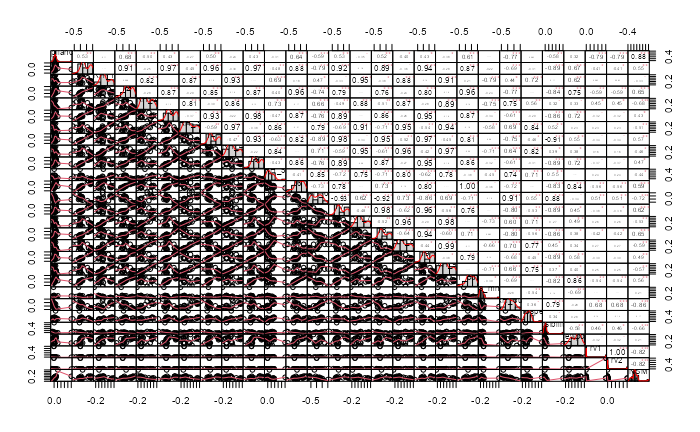

```r
# Análise Estatística - Correlação
data_nub <- numeric.vars <- c('Appliances','T1','RH_1','T2',
                  'RH_2','T3','RH_3','T4','RH_4',
                  'T5','RH_5','T6','RH_6','T7',
                  'RH_7','T8','RH_8','T9','RH_9',
                  'T_out','Press_mm_hg','RH_out','Windspeed',
                  'Visibility','Tdewpoint',
                  'rv1','rv2','NSM')
data_corr <- cor(data[,data_nub])

# Visualizando correlação com "Spearman"
chart.Correlation(data_corr,
                  method="spearman",
                  histogram=TRUE,
                  pch=16)
```

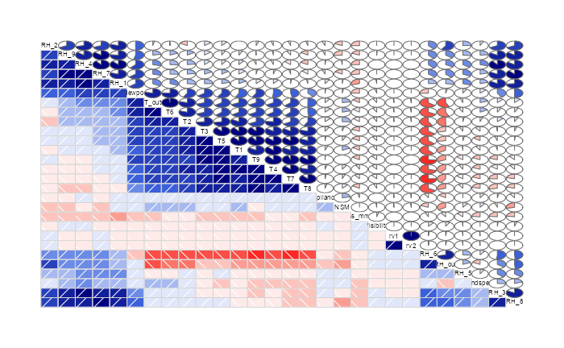

```r
# Visualizando correlação com dados númericos
data_corr <- corrgram(data_corr, order=TRUE,
         lower.panel = panel.shade,
         upper.panel = panel.pie,
         text.panel = panel.txt)
```

# Observações da Correlação

Neste texto, serão apresentadas algumas observações relevantes sobre as correlações existentes entre as variáveis do conjunto de dados, especialmente em relação ao atributo-alvo “Appliances”:

- Temperaturas: Todas as características relacionadas às temperaturas apresentam uma correlação positiva com o atributo-alvo “Appliances”. Isso significa que, à medida que as temperaturas aumentam, é provável que o consumo de energia dos eletrodomésticos também aumente, e vice-versa.
- Atributos do Tempo: Algumas características relacionadas ao tempo, como Visibility, Tdewpoint e Press_mm_hg, mostraram uma correlação baixa com o atributo-alvo “Appliances”. Isso indica que essas variáveis têm uma influência limitada ou pouco significativa sobre o consumo de energia dos eletrodomésticos.
- Umidade: A análise revelou que as variáveis relacionadas à umidade não possuem correlação significante com o atributo-alvo “Appliances”. Ou seja, o nível de umidade do ambiente não parece ter uma influência direta sobre o consumo de energia dos eletrodomésticos. Valores próximos a 0.9 são frequentemente considerados como um limiar para correlações significativas, e como não atingem esse valor, a umidade não é um fator determinante para o consumo de energia.
- Variáveis Randômicas: Foi constatado que as variáveis aleatórias não apresentam influência ou correlação significativa com o atributo-alvo “Appliances”. Essas variáveis podem ser consideradas como ruído ou informações irrelevantes para a previsão do consumo de energia dos eletrodomésticos.

Essas observações sobre a correlação entre as variáveis são fundamentais para a construção e interpretação de modelos preditivos ou análises mais complexas. Ao identificar quais características têm maior ou menor impacto no atributo-alvo, é possível direcionar esforços para aprimorar modelos ou entender melhor os fatores que influenciam o consumo de energia, auxiliando em tomadas de decisão mais informadas.

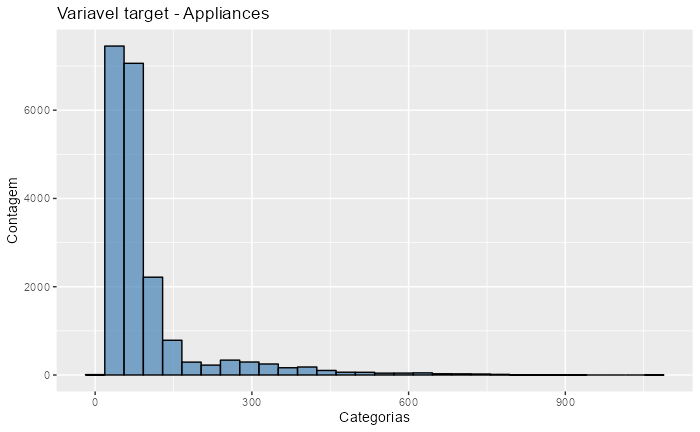

```r
# Gráfico variavel target "Appliances"
ggplot(data, aes(x = Appliances)) +
  geom_histogram(fill = "steelblue", color = "black", alpha = 0.7) +
  labs(title = "Variavel target - Appliances",
       x = "Categorias",
       y = "Contagem")
```

# Análise série temporal

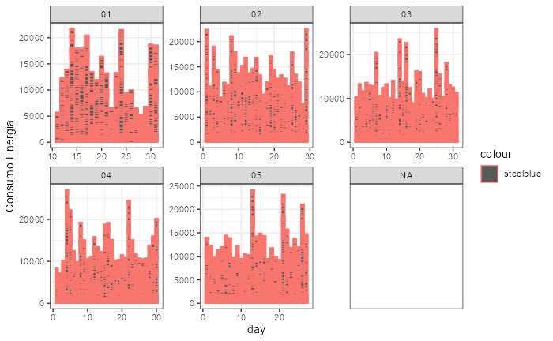

```r
# Visualizando o consumo de energia por dia x mes
ggplot(data)+
  geom_bar(aes(x=day, y=Appliances, color = "steelblue"), stat="identity")+
  scale_y_continuous(name="Consumo Energia")+
  facet_wrap(~month, scale="free")+
  theme_bw()
```

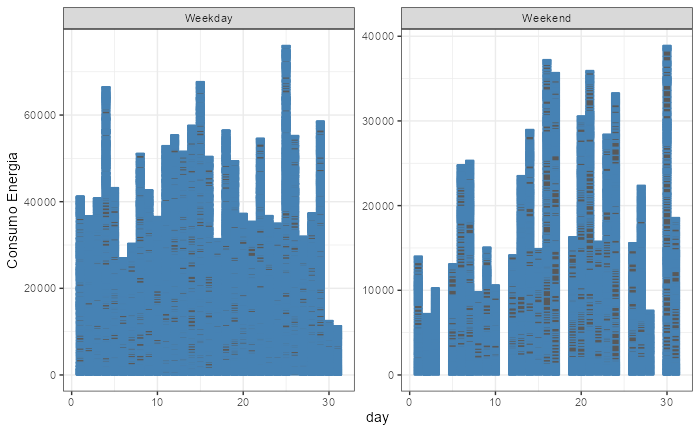

```r
# Visualizando o consumo de energia por dia x semana e final de semana
ggplot(data)+
  geom_bar(aes(x=day, y=Appliances), stat="identity", color = "steelblue")+
  scale_y_continuous(name="Consumo Energia")+
  facet_wrap(~WeekStatus, scale="free")+
  theme_bw()
```

# Parte 6 - Seleção de variaveis

## Parte 6.0 Normalização dados

```r
# Normalização
scale.features <- function(data, variables){
  for (variable in variables){
    data[[variable]] <- scale(data[[variable]], center=T, scale=T)
  }
  return(data)
}

# Variaveis para normalização dados
norml_data <- numeric.vars <- c('T1','RH_1','T2','RH_2','T3','RH_3','T4','RH_4','T5','RH_5','T6','RH_6','T7','RH_7','T8','RH_8','T9','RH_9',
                  'T_out','Press_mm_hg','RH_out','Windspeed','Visibility','Tdewpoint','rv1','rv2','NSM')
# Normalização dados
data <- scale.features(data, norml_data)
data
```

| date | Appliances | lights | T1 | RH_1 | T2 | RH_2 | T3 | RH_3 | T4 | RH_4 | T5 | RH_5 | T6 | RH_6 | T7 | RH_7 | T8 | RH_8 | T9 | RH_9 | T_out | Press_mm_hg | RH_out | Windspeed | Visibility | Tdewpoint | rv1 | rv2 | NSM | … |
| --- | --- | --- | --- | --- | --- | --- | --- | --- | --- | --- | --- | --- | --- | --- | --- | --- | --- | --- | --- | --- | --- | --- | --- | --- | --- | --- | --- | --- | --- | --- |
| 2016-01-11 17:00:00 | 60 | 30 | -1.118616411 | 1.843774e+00 | -0.520398193 | 1.073656229 | -1.23503214 | 1.686087248 | -0.908193656 | 1.5063994118 | -1.314869923 | 0.471148438 | -0.145192503 | 0.951774255 | -1.4536095613 | 1.219830405 | -1.95745918 | 1.1415434334 | -1.2172928 | 0.958111962 | -0.1526428727 | -2.97625226 | 0.822059592 | 1.20766294 | 2.0915434241 | 0.366965999 | -0.807953104 | -0.807953104 | 0.73347455 | … |
| 2016-01-11 17:10:00 | 60 | 30 | -1.118616411 | 1.616766e+00 | -0.520398193 | 1.057070699 | -1.23503214 | 1.704522827 | -0.908193656 | 1.6044878433 | -1.314869923 | 0.471148438 | -0.176936728 | 0.945567689 | -1.4536095613 | 1.206794825 | -1.95745918 | 1.1345250308 | -1.2007478 | 0.965338271 | -0.1745833837 | -2.96273772 | 0.822059592 | 1.07167627 | 1.7665392072 | 0.343126096 | -0.440228991 | -0.440228991 | 0.75753227 | … |
| 2016-01-11 17:20:00 | 50 | 30 | -1.118616411 | 1.517921e+00 | -0.520398193 | 1.033523341 | -1.23503214 | 1.748563375 | -0.944090612 | 1.5808775164 | -1.314869923 | 0.458956066 | -0.221816494 | 0.916461033 | -1.4536095613 | 1.182027224 | -1.95745918 | 1.1090035667 | -1.2338377 | 0.950885654 | -0.1965238948 | -2.94922319 | 0.822059592 | 0.93568960 | 1.4415349902 | 0.319286192 | 0.252102296 | 0.252102296 | 0.78158999 | … |
| 2016-01-11 17:40:00 | 60 | 40 | -1.118616411 | 1.526298e+00 | -0.520398193 | 1.009771223 | -1.23503214 | 1.769047351 | -0.962039090 | 1.4979534412 | -1.296799386 | 0.458956066 | -0.253560719 | 0.972213120 | -1.4536095613 | 1.142268705 | -2.00857970 | 1.0822060295 | -1.2338377 | 0.926797959 | -0.2404049169 | -2.92219412 | 0.822059592 | 0.66371625 | 0.7915265564 | 0.271606385 | -1.028096390 | -1.028096390 | 0.82970542 | … |
| 2016-01-11 17:50:00 | 50 | 40 | -1.118616411 | 1.449232e+00 | -0.520398193 | 1.002399876 | -1.23503214 | 1.748563375 | -0.962039090 | 1.5440223719 | -1.332940460 | 0.452305681 | -0.264507004 | 1.000249677 | -1.4852052379 | 1.148134716 | -2.00857970 | 1.0822060295 | -1.2338377 | 0.900301495 | -0.2623454279 | -2.90867958 | 0.822059592 | 0.52772958 | 0.4665223395 | 0.247766481 | 1.374901991 | 1.374901991 | 0.85376314 | … |
| 2016-01-11 18:10:00 | 60 | 50 | -1.139371062 | 1.331958e+00 | -0.520398193 | 1.002399876 | -1.26494076 | 1.738321387 | -0.962039090 | 1.5747349923 | -1.351010997 | 0.437896514 | -0.282568373 | 1.021330601 | -1.5010030762 | 1.136402694 | -2.00857970 | 1.0822060295 | -1.2338377 | 0.900301495 | -0.2811515803 | -2.88615536 | 0.810874726 | 0.45973624 | 0.1415181226 | 0.219953260 | 0.555429365 | 0.555429365 | 0.90187858 | … |
| 2016-01-11 18:20:00 | 60 | 40 | -1.180880366 | 1.341382e+00 | -0.520398193 | 0.986019105 | -1.26494076 | 1.704522827 | -0.962039090 | 1.5578430510 | -1.314869923 | 0.448980489 | -0.293514657 | 1.047119953 | -1.4694073996 | 1.175509434 | -2.00857970 | 1.0822060295 | -1.2338377 | 0.900301495 | -0.2780172216 | -2.87714567 | 0.799689860 | 0.52772958 | 0.1415181226 | 0.215979943 | 0.446149690 | 0.446149690 | 0.92593630 | … |
| 2016-01-11 18:30:00 | 70 | 40 | -1.139371062 | 1.465148e+00 | -0.506718137 | 0.977828720 | -1.23503214 | 1.727055200 | -0.962039090 | 1.6284820780 | -1.351010997 | 0.448980489 | -0.282568373 | 1.059961125 | -1.4536095613 | 1.195062803 | -2.00857970 | 1.0822060295 | -1.2338377 | 0.900301495 | -0.2748828628 | -2.86813598 | 0.788504994 | 0.59572292 | 0.1415181226 | 0.212006626 | -1.510607233 | -1.510607233 | 0.94999402 | … |
| 2016-01-11 19:00:00 | 430 | 50 | -0.967107452 | 1.945132e+00 | -0.353197513 | 0.977828720 | -1.18518444 | 1.738321387 | -0.908193656 | 1.6899073188 | -1.351010997 | 0.458956066 | -0.293514657 | 1.090886946 | -1.1581899852 | 1.975894031 | -2.02561987 | 1.0764637001 | -1.2520372 | 0.900301495 | -0.2654797867 | -2.84110691 | 0.754950397 | 0.79970293 | 0.1415181226 | 0.200086674 | 0.645881585 | 0.645881585 | 1.02216717 | … |
| 2016-01-11 19:10:00 | 250 | 40 | -0.888239775 | 3.132946e+00 | -0.278717210 | 1.149826814 | -1.18518444 | 1.920628773 | -0.908193656 | 1.8880037205 | -1.351010997 | 0.467084314 | -0.302682171 | 1.078848348 | -1.0918390644 | 2.106249828 | -2.04266004 | 1.0968808713 | -1.2884361 | 0.909133650 | -0.2654797867 | -2.82533995 | 0.721395799 | 0.79970293 | 0.1415181226 | 0.180220088 | -0.398909680 | -0.398909680 | 1.04622489 | … |

[output cut: 990 more lines]

```r
# Treino teste modelo
data_splits <- createDataPartition(data$Appliances,
                                   p=0.7,
                                   list = FALSE)
```

```r
# Dados treino e teste
train <- data[data_splits,]
test <- data[-data_splits,]
```

[output not shown]

```r
# Verificando dados treino e teste
nrow(train)
```

```
[1] 13817
```

```r
nrow(test)
```

```
[1] 5918
```

# Parte 6.1 - Limpeza de dados

```r
train <- na.omit(train)
```

```r
mean_value <- mean(train$Appliances, na.rm = TRUE)
train$Appliances[is.na(train$Appliances)] <- mean_value
```

# Parte 7 - Modelo machine learning

**Modelo 1 - Machine learning 1 - Random forest**

```r
# Importando biblioteca
library(randomForest)

# Criando modelo Random forest
modelo_rf <- randomForest(Appliances ~ .,
                          data = train,
                          ntree = 100)

# Visualizando modelo RF
summary(modelo_rf)
```

[output not shown]

```r
# Ver os atributos mais importantes
importance(modelo_rf)
```

[output not shown]

```r
# Fazendo previsões com o modelo
previsoes <- predict(modelo_rf,
                     newdata = test,
                     n.trees = 100)
previsoes
```

[output not shown]